# Assignment1- Reproducible Research

Aniruddha Amrite

January 4, 2017

```r
library(ggplot2)
```

The following code chunk sets the working directory and reads in the dataset

```r
setwd("H:/Personal/Continuing Education/Data Scientist Specialization/Reproducible Research")
data<-read.csv("activity.csv", stringsAsFactors = F)
str(data)
```

```
## 'data.frame':    17568 obs. of  3 variables:
##  $ steps   : int  NA NA NA NA NA NA NA NA NA NA ...
##  $ date    : chr  "2012-10-01" "2012-10-01" "2012-10-01" "2012-10-01" ...
##  $ interval: int  0 5 10 15 20 25 30 35 40 45 ...
```

```r
data$date<-as.POSIXct(data$date) #convert the date to a posixCT data format from character
```

## Total number of steps taken per day

The following code calculates the total number of steps taken each day and plots a histogram and calculates the mean and median total steps per day

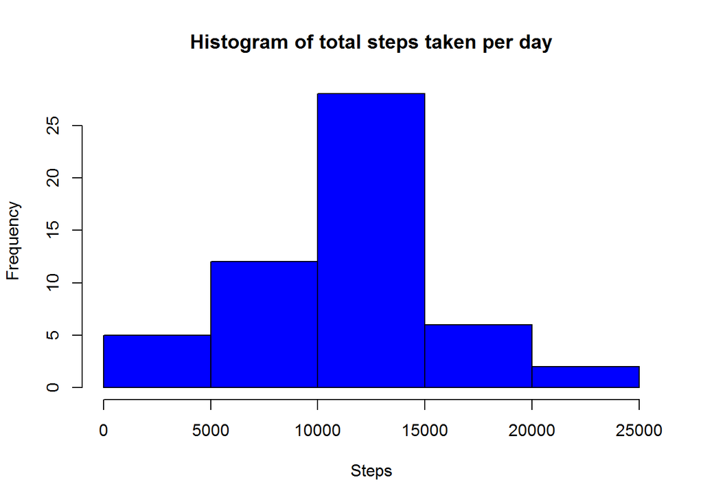

```r
stepsd<-with(data,aggregate(steps~date, FUN=sum))
hist(stepsd$steps, main="Histogram of total steps taken per day", xlab="Steps", col="blue")
```

```r
meanTotalSteps<-with(stepsd,mean(steps, na.rm=T))
medianTotalSteps<-with(stepsd,median(steps, na.rm=T))
print(paste("Mean Total Steps per day =",meanTotalSteps, Sep=""))
```

```
## [1] "Mean Total Steps per day = 10766.1886792453 "
```

```r
print(paste("Median Total Steps per day =",medianTotalSteps, Sep=""))
```

```
## [1] "Median Total Steps per day = 10765 "
```

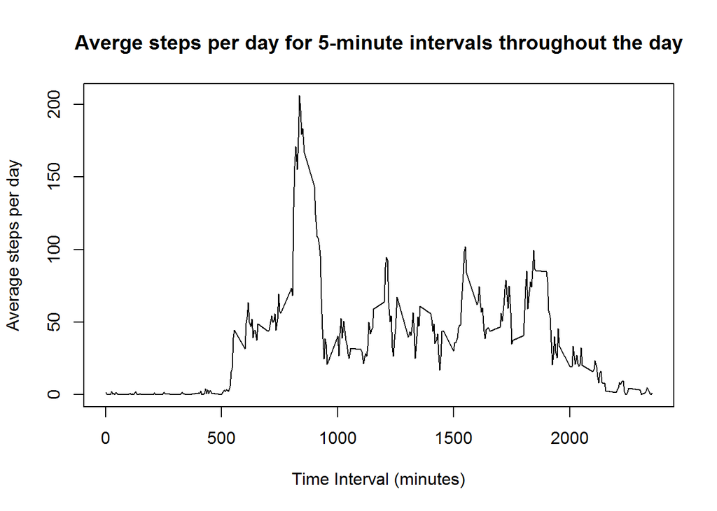

```r
stepsi<-with(data,aggregate(steps~interval, FUN=mean))
plot(stepsi$interval,stepsi$steps,type="l", main="Averge steps per day for 5-minute intervals throughout the day",
     xlab="Time Interval (minutes)", ylab="Average steps per day")
```

```r
print (paste("The interval containing on avergae the maximum number of steps is",stepsi$interval[stepsi$steps==max(stepsi$steps)],sep=" "))
```

```
## [1] "The interval containing on avergae the maximum number of steps is 835"
```

Thus on average the higest activity happens around 8:35 to 8:40 AM (assuming interval 0 is 00:00 midnight to 00:05)

## Imputing Missing Values

The missing values for the steps in the dataset will be replaced by the mean missing value for that interval across all days. The code chunk below replaces the NA values with the mean for that time interval across all days.

```r
TotalMissingValues<-sum(!complete.cases(data))
print(paste("The total number of NAs in the dataset is ", TotalMissingValues, sep=" "))
```

```
## [1] "The total number of NAs in the dataset is  2304"
```

```r
dataNA<-subset(data, is.na(data$steps))# asubset for all the NA values
dataNA<-merge(stepsi,dataNA, by="interval")#merge with the mean values across interval dataset created in previous chunk
dataNA$steps.y<-NULL #delete this column
datanotNA<-subset(data, !is.na(data$steps)) # subset without the NA values
colnames(dataNA)[colnames(dataNA)=="steps.x"]<-"steps" # rename the column to "steps"
dataNA<-dataNA[c("steps","date","interval")]# reorder the columns so that both the subsets have same order
data1<-rbind(datanotNA,dataNA)# combine the subsets to get the dataset
data1<-data1[order(data1$date,data1$interval),] # sort the dataset in the correct order.
```

## Total number of steps taken per day after imputation of NA values

The following code calculates the total number of steps taken each day and plots a histogram and calculates the mean and median total steps per day

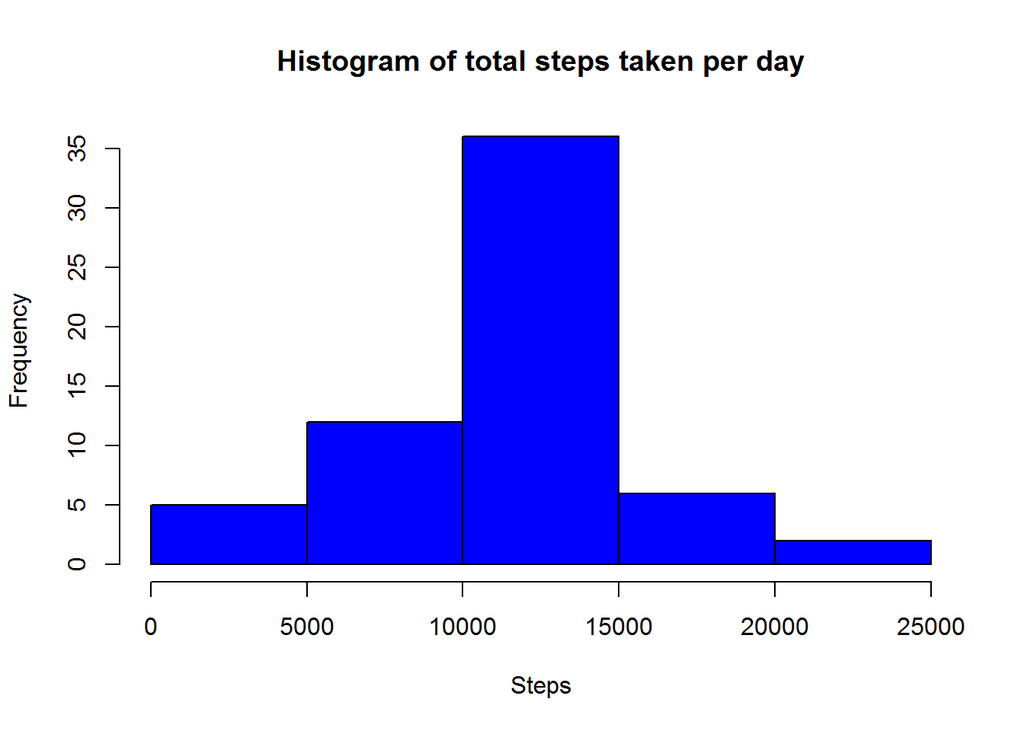

```r
stepsd1<-with(data1,aggregate(steps~date, FUN=sum))
hist(stepsd1$steps, main="Histogram of total steps taken per day", xlab="Steps", col="blue")
```

```r
meanTotalSteps1<-with(stepsd1,mean(steps, na.rm=T))
medianTotalSteps1<-with(stepsd1,median(steps, na.rm=T))
print(paste("Mean Total Steps per day =",meanTotalSteps1, Sep=""))
```

```
## [1] "Mean Total Steps per day = 10766.1886792453 "
```

```r
print(paste("Median Total Steps per day =",medianTotalSteps1, Sep=""))
```

```
## [1] "Median Total Steps per day = 10766.1886792453 "
```

The impact of substituting the NA values with mean of the interval data is just to change the frequency of occurence in the histogram. The mean and the median values for the total steps per day do not change significantly after imputation.

## Are there activity differences between the weekdays and weekends

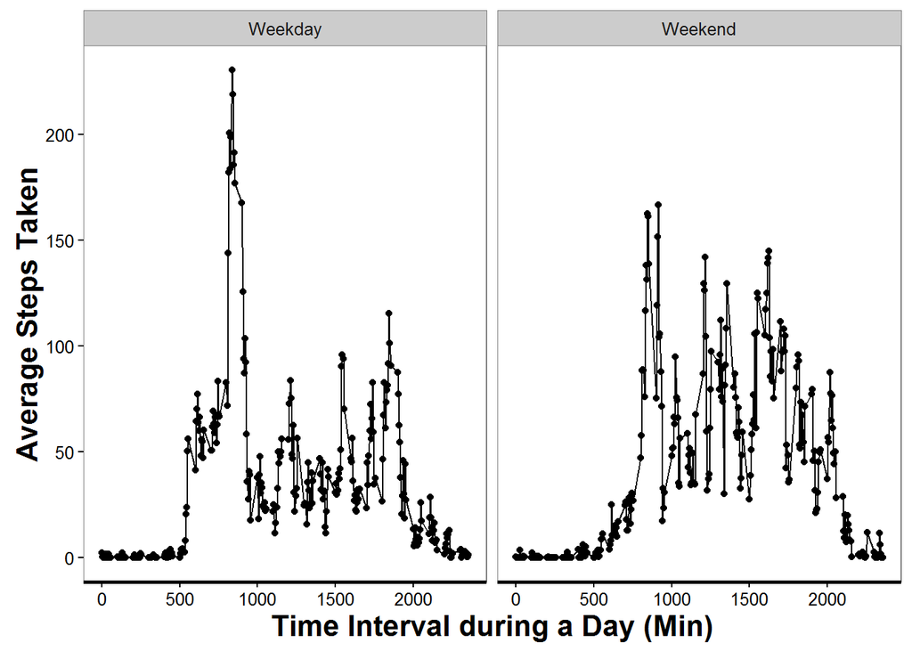

```r
data1$weekday<-weekdays(data1$date)
data1$day<-ifelse(data1$weekday %in% c("Saturday", "Sunday"), "Weekend","Weekday")
stepsi1<-with(data1,aggregate(steps~interval+day, FUN=mean))

ggplot(data=stepsi1, aes(x=interval, y=steps), group=1)+
    geom_point()+
  geom_line(aes(group=1))+
       facet_grid(.~day)+
  theme_bw()+
  theme(
    plot.background = element_blank()
    ,panel.grid.major = element_blank()
    ,panel.grid.minor = element_blank()
    ,axis.line.x = element_line(color="black", size = 1)
    ,axis.title.x= element_text(face="bold",size=16)
    ,axis.title.y= element_text(face="bold",size=16))+
  xlab("Time Interval during a Day (Min)")+
  ylab("Average Steps Taken")
```

During the weekday the average steps taken are more in the early part of the day as compared to throughout the day whereas during the weekend they appear to be evenly spread out throughout the day